# Data 624 Project 1

Anthony Pagan

3/29/2020

# Project 1 Description

This project consists of 3 parts - two required and one bonus and is worth 15% of your grade. The project is due at 11:59 PM on Sunday March 31. I will accept late submissions with a penalty until the meetup after that when we review some projects. Part A – ATM Forecast, ATM624Data.xlsx

In part A, I want you to forecast how much cash is taken out of 4 different ATM machines for May 2010. The data is given in a single file. The variable ‘Cash’ is provided in hundreds of dollars, other than that it is straight forward. I am being somewhat ambiguous on purpose to make this have a little more business feeling. Explain and demonstrate your process, techniques used and not used, and your actual forecast. I am giving you data via an excel file, please provide your written report on your findings, visuals, discussion and your R code via an RPubs link along with the actual.rmd file Also please submit the forecast which you will put in an Excel readable file.

# Functions

In this section we begin by creating the 3 functions that will be use throughout this project:

- Check Data
- Model Data
- Train Data

## CheckData

In this chunck we create a checkdata function to display all the plots for each data set. The plots include:

- Autoplot
- Check Residuals
- PCF Plot
- GGSeasonal
- GG Series
- Auto and Checkresiduals plots with Box Cox Lambda Transform
- Additive Seasonality Plot
- KPSS test data

```r
checkdata<- function (x)
    {
    print("Plot Data, Check Residuals , ACF ,PCF, seasonal and series Plots")
    print(autoplot(x)) #Plot data
    print(checkresiduals(x)) # Check residuals
    print(ggPacf(x))# Add ggPacf details
    print(ggsubseriesplot(x))#seasonal plots
    print(ggseasonplot(x, xlab = "Daily")+ theme(legend.title = element_blank()))#series plot

    print("Box Cox plots with Lambda")
    l<-BoxCox.lambda(x) # Get lambda value for boxcox
    print(autoplot(BoxCox(x, l))) # Plot boxcox wiht lambda
    print(checkresiduals(BoxCox(x, l))) # check residuals with boxcox transform

    print("Plot data and seasonality Trends")
    print(BoxCox(x, l) %>% decompose(type="additive")%>%
    autoplot(frequency = frequency(atm)) + xlab("Month") +
    ggtitle("Monthy ATM Cash in Thousands"))

    print("Check if data or diff data is stationary")
    print(x %>% ur.kpss() %>% summary) # Check if data is stationary
    print(x %>% diff() %>%ur.kpss() %>% summary) # add a difference
    print(kpss.test(atm1, null = "Trend")) # KPSS test

    }
```

## Model Functon

In this section we build a basic functions to generate following 6 models:

- Mean
- NAIVE
- SNAIVE
- Simple Exponential Smoothing (SES)
- Error Trend Seasonality (ETS)
- Autoregressive Integrated Moving Average (ARIMA)

```r
#Prepare 6 models
modfunc<- function (x, h)
    {
    l<-BoxCox.lambda(x)
    m1<<-meanf(x,h=h,lambda=l)
    m2<<-rwf(x,h=h,lambda=l)
    m3<<-snaive(x,h=h,lambda=l)
    m4<<- ses(x,h=h,lambda=l)
    m5<<- ets(x,lambda=l)
    m6<<- auto.arima(x,lambda=l)


    #Print plots for all models with forecast
    print(autoplot(window(x))+
      autolayer(m1, series = "Mean", PI=FALSE) +
      autolayer(m2, series = "Naive", PI=FALSE) +
      autolayer(m3, series = "Seasonal naive", PI=FALSE) +
      autolayer(m4, series = "Simple Exp Smoothing", PI=FALSE) +
      xlab("Year") + ylab("ATM") +
      ggtitle("Forecasts for ATM") +
      guides(colur=guide_legend(title="Forecast")))

    print(autoplot(forecast(m5, h=h)))
    print(autoplot(forecast(m6, h=h)))
    }
```

## Train Function

In this section we begin with with functions for ETS and ARIMA models to caculate the Mean Squared Errors. The trainst function create training datasets, models and extracts stastics for final analysis.

```r
#ETS ARIMA functions
fets<- function(x, h)
{
    forecast(ets(x), h=h)
}

arima1<- function(x, h)
{
    forecast(Arima(x, order=m6tr$arma[1:3]), h=h)
}

#Setup Training Model and extract RMSE and Acuracy Info
traintst<- function(x,h)
{   l<<-BoxCox.lambda(x)
    train<- subset(x, end = nrow(x)*.7)
    m1tr<<-meanf(train,h=h,lambda=l)
    m2tr<<-rwf(train,h=h, lambda=l)
    m3tr<<-snaive(train,h=h, lambda=l)
    m4tr<<-ses(train,h=h, lambda=l)
    m5tr<<-ets(train)
    m6tr<<-auto.arima(train, lambda = l)

    e<-tsCV(x, forecastfunction = meanf, h = h)
    print ( c('MEAN MSE:', round(mean(e^2 , na.rm = TRUE),2)))
    f<-tsCV(x, forecastfunction = rwf, h = h)
    print ( c('NAIVE MSE:', round(mean(f^2 , na.rm = TRUE),2)))
    g<-tsCV(x, forecastfunction = snaive, h = h)
    print ( c('SNAIVE MSE:', round(mean(g^2 , na.rm = TRUE),2)))
    s<-tsCV(x, forecastfunction = ses, h=h)
    print ( c('Simple Exp Smooth MSE:', round(mean(s^2 , na.rm = TRUE),2)))
    #t<-window(x)
    e1<-tsCV(x, fets, h=h)
    e2<-tsCV(x, arima, h=h, window=1)
    print(c('ETS MSE:', round(mean(e1^2, na.rm=TRUE),2)))
    print(c('ARIMA MSE:', round(mean(e2^2, na.rm=TRUE),2)))
    print(c('ETS AIC/BIC:',m5tr$aicc, m5tr$bic))
    print(c('ARIMA AIC/BIC:',m6tr$aicc, m6tr$bic))

    print(list('Model1 MEAN:',m1tr%>%forecast(h)%>%accuracy(x),
               'Model2 NAIVE:',m2tr%>%forecast(h)%>%accuracy(x),
               'Model3 SNAIVE:',m3tr%>%forecast(h)%>%accuracy(x),
               'Model4 SES:',m4tr%>%forecast(h)%>%accuracy(x),
               'Model5 ETS:',m5tr%>%forecast(h)%>%accuracy(x),
               'Model6 ARIMA:',m6tr%>%forecast(h)%>%accuracy(x)))
}
```

# ATM

## ATM Data Preparation

### ( Step 1)

We begin by preparing the data and generatin some summary data and preliminary plots. The summary data show a couple of rows with no data. We also see that ATM numbers are in each row rather than being listed by column.

```r
atmn <- read_excel("ATM624Data.xlsx")
summary(atmn)
```

```
##       DATE           ATM                 Cash
##  Min.   :39934   Length:1474        Min.   :    0.0
##  1st Qu.:40026   Class :character   1st Qu.:    0.5
##  Median :40118   Mode  :character   Median :   73.0
##  Mean   :40118                      Mean   :  155.6
##  3rd Qu.:40210                      3rd Qu.:  114.0
##  Max.   :40312                      Max.   :10919.8
##                                     NA's   :19
```

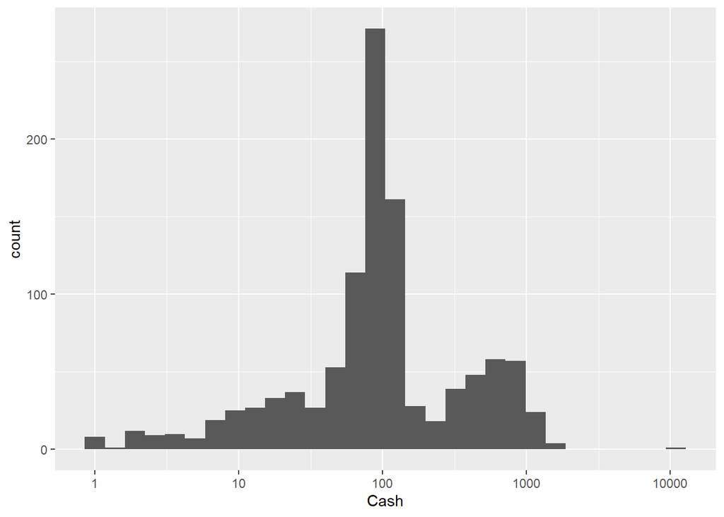

```r
atm<-atmn[complete.cases(atmn),]
ggplot(atm, aes(Cash)) + geom_histogram() + scale_x_log10()
```

### (Step 2)

In this chunk we used spread to set the ATM rows as columns. We run a summary which shows there are a couple of rows with no data so we use complete.cases function to only use rows with complete data, then run another summary to confirm.

```r
atm<-spread(atm, ATM, Cash)
summary(atm)
```

```
##       DATE            ATM1             ATM2             ATM3
##  Min.   :39934   Min.   :  1.00   Min.   :  0.00   Min.   : 0.0000
##  1st Qu.:40025   1st Qu.: 73.00   1st Qu.: 25.50   1st Qu.: 0.0000
##  Median :40116   Median : 91.00   Median : 67.00   Median : 0.0000
##  Mean   :40116   Mean   : 83.89   Mean   : 62.58   Mean   : 0.7206
##  3rd Qu.:40207   3rd Qu.:108.00   3rd Qu.: 93.00   3rd Qu.: 0.0000
##  Max.   :40298   Max.   :180.00   Max.   :147.00   Max.   :96.0000
##                  NA's   :3        NA's   :2
##       ATM4
##  Min.   :    1.563
##  1st Qu.:  124.334
##  Median :  403.839
##  Mean   :  474.043
##  3rd Qu.:  704.507
##  Max.   :10919.762
##
```

```r
atm<-atm[complete.cases(atm),]
summary(atm)
```

```
##       DATE            ATM1             ATM2             ATM3
##  Min.   :39934   Min.   :  1.00   Min.   :  0.00   Min.   : 0.0000
##  1st Qu.:40029   1st Qu.: 73.00   1st Qu.: 25.00   1st Qu.: 0.0000
##  Median :40119   Median : 91.00   Median : 66.00   Median : 0.0000
##  Mean   :40118   Mean   : 84.11   Mean   : 62.37   Mean   : 0.7306
##  3rd Qu.:40208   3rd Qu.:108.00   3rd Qu.: 93.25   3rd Qu.: 0.0000
##  Max.   :40298   Max.   :180.00   Max.   :147.00   Max.   :96.0000
##       ATM4
##  Min.   :    1.563
##  1st Qu.:  127.719
##  Median :  404.587
##  Mean   :  476.786
##  3rd Qu.:  705.284
##  Max.   :10919.762
```

### (Step 3)

We now now run the TS funciton to set the Time series to a fequency of 365 and a start of year 2009 with 120 to set to may. We run an autoplot with all ATMs together and another plot with ATM separate by setting facets to true.

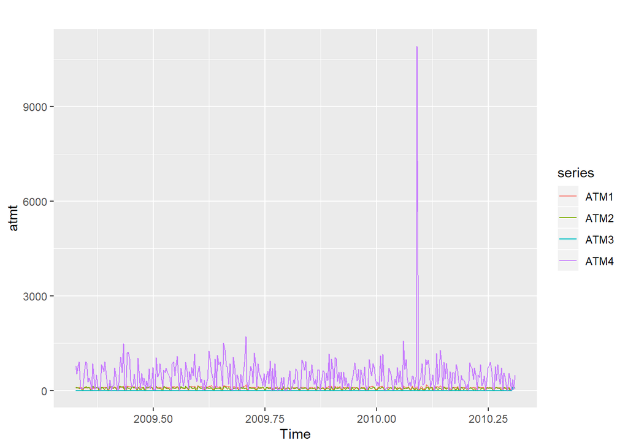

```r
atmt<-ts(atm[,-1],frequency=365, start = c(2009,120))
autoplot(atmt)
```

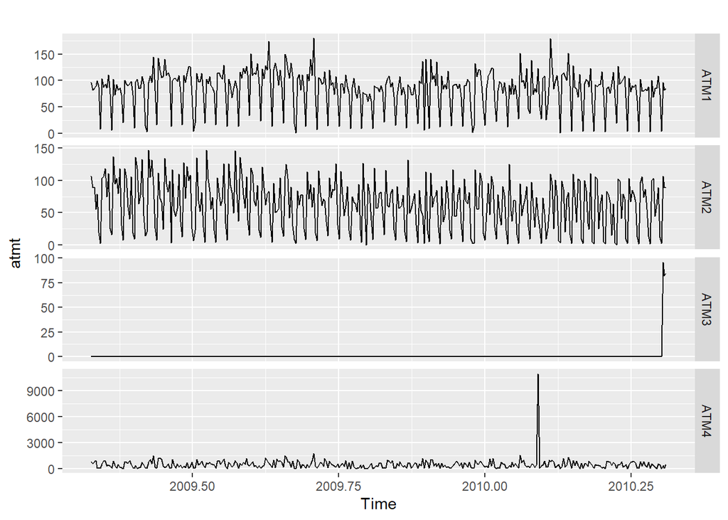

```r
autoplot(atmt, facets = TRUE)
```

### (Step 4)

In this section we are splitting the dataset based on ATM1 - ATM4. We set frequency to 30 days for 30 days , as start of 5 for May and 12 for monthly.

```r
atm1 <- ts(atm[,"ATM1"],frequency=30, start=c(5,12))
atm2 <- ts(atm[,"ATM2"],frequency=30, start=c(5,12))
atm3 <- ts(atm[,"ATM3"],frequency=30, start=c(5,12))
atm4 <- ts(atm[,"ATM4"],frequency=30, start=c(5,12))
```

## Diagnostics ATM1

### Check Data

In the check data portion for ATM1, we can see the basic autoplot for the original data shows some seasonality while regression plot shows a residuals are left skewed. The ACF plot shows a decreasing trend while PAcf is fairly stationary. The series plot is an up and down trend. The second checkresddual plot includes a Box Cox transformation based on box.cox.lambda function. The residual seems to stabalize a bit. The seasonal additive plot confirms the seasonality of the data with no trend. The KPSS unit test shows that the original data is significant with 1 difference added.

```r
checkdata(atm1)
```

```
## [1] "Plot Data, Check Residuals , ACF ,PCF, seasonal and series Plots"
```

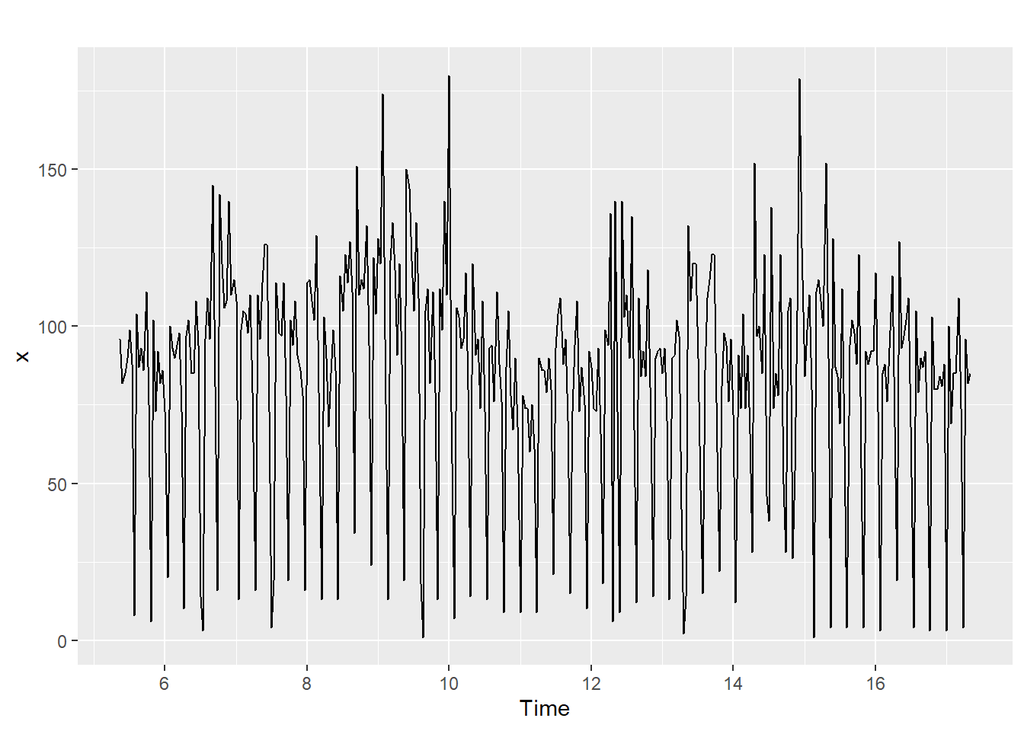

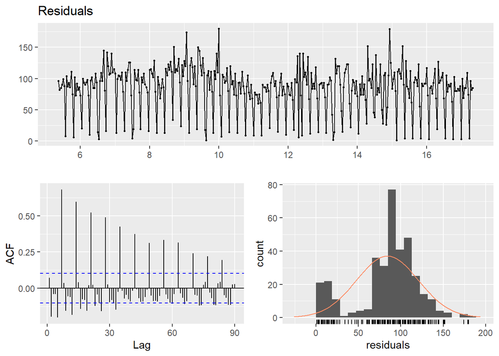

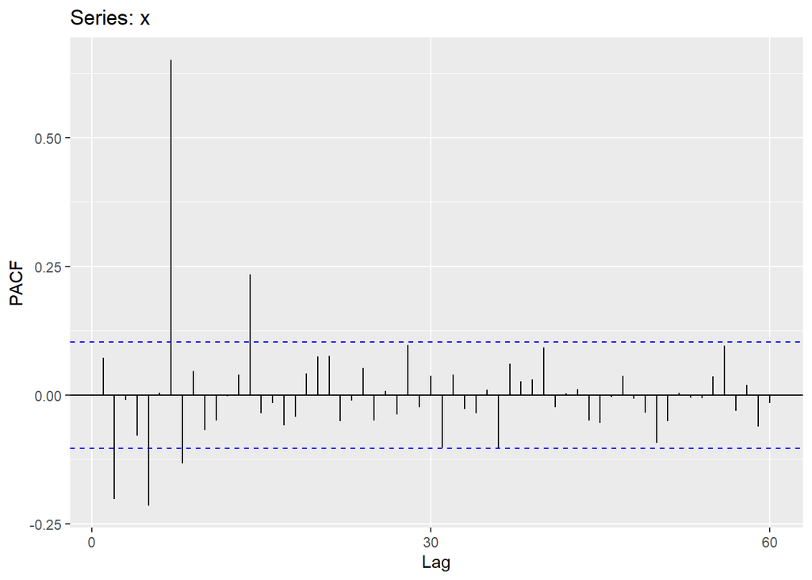

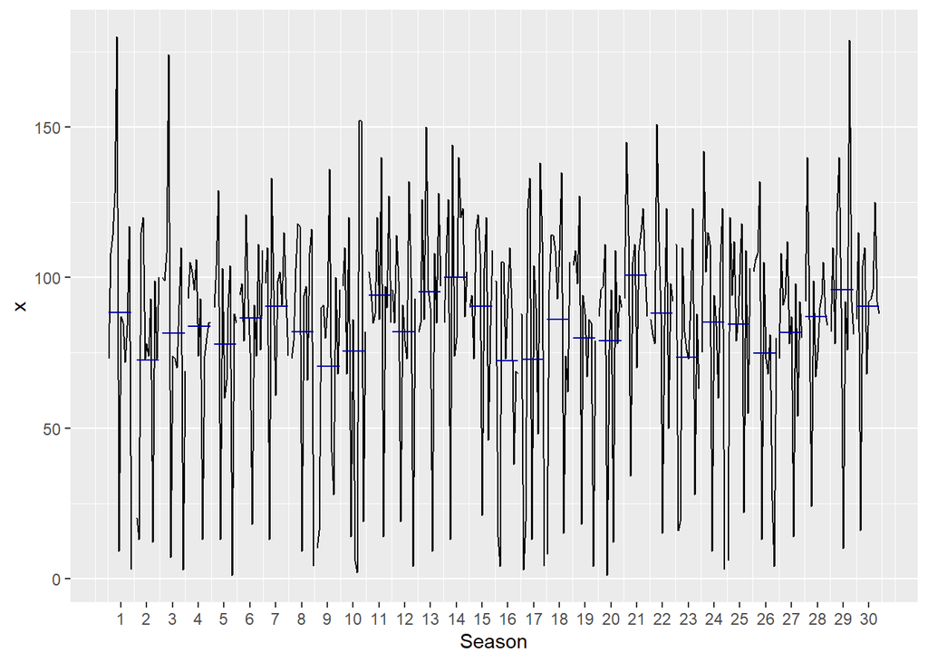

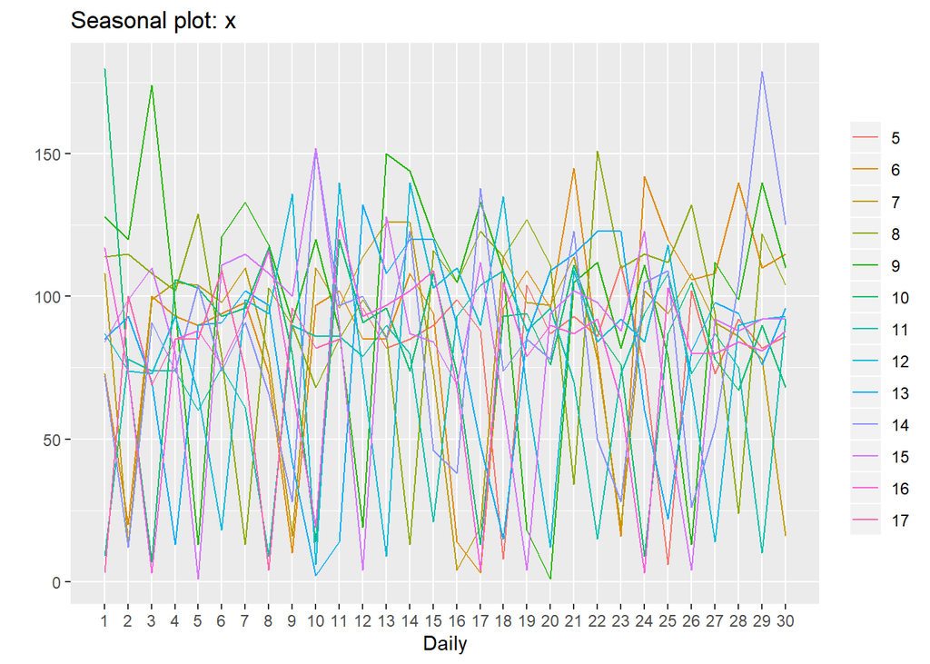

```
## [1] "Box Cox plots with Lambda"
```

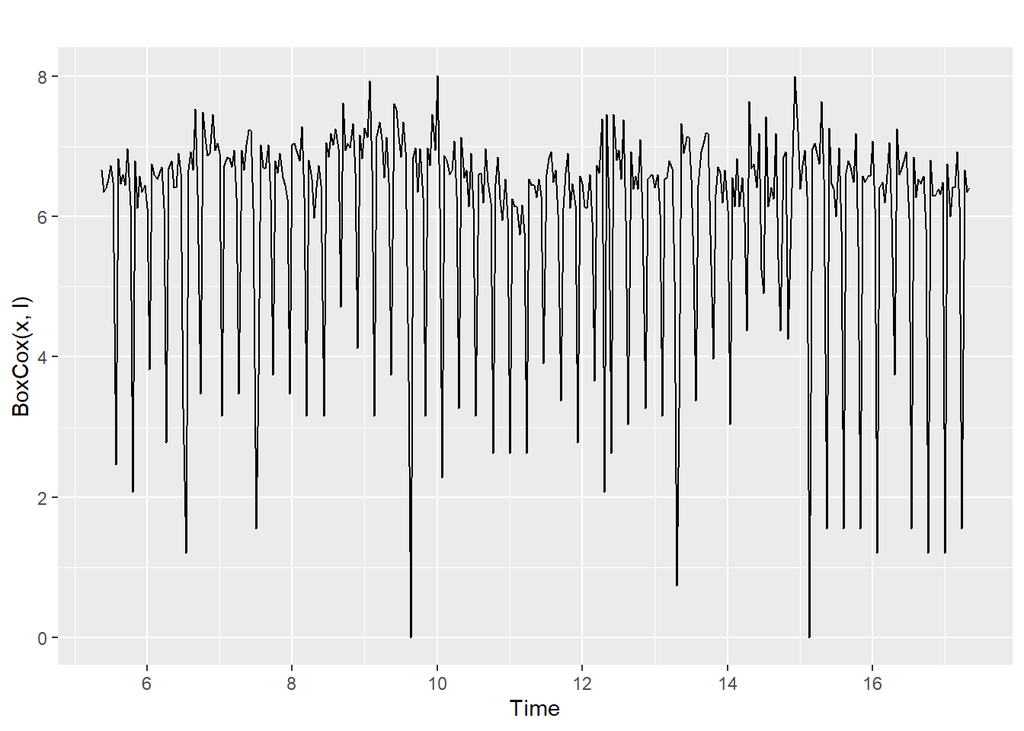

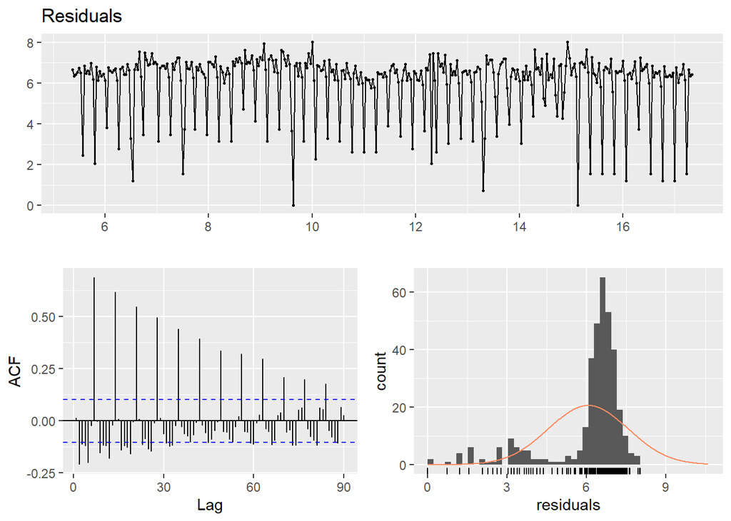

```
## NULL
## [1] "Plot data and seasonality Trends"
```

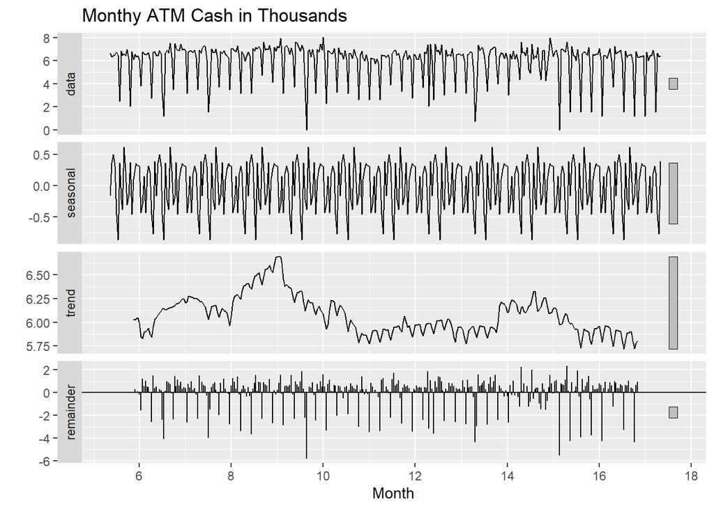

```
## [1] "Check if data or diff data is stationary"
##
## #######################
## # KPSS Unit Root Test #
## #######################
##
## Test is of type: mu with 5 lags.
##
## Value of test-statistic is: 0.5005
##
## Critical value for a significance level of:
##                 10pct  5pct 2.5pct  1pct
## critical values 0.347 0.463  0.574 0.739
##
##
## #######################
## # KPSS Unit Root Test #
## #######################
##
## Test is of type: mu with 5 lags.
##
## Value of test-statistic is: 0.0085
##
## Critical value for a significance level of:
##                 10pct  5pct 2.5pct  1pct
## critical values 0.347 0.463  0.574 0.739
##
##
##  KPSS Test for Trend Stationarity
##
## data:  atm1
## KPSS Trend = 0.12892, Truncation lag parameter = 5, p-value = 0.08163
```

### Model Data

Visually modeling plots point to SNaive as the possible best model for this dataset when comparing MEAN, NAIVE, SNAIVE and SES. In the visual comparison of ETS and ARIMA, ETS results in an additive model and ARIMA results in a 2,0,2 non-zero mean model. The plot hints that ARIMA may follow the forecast better.

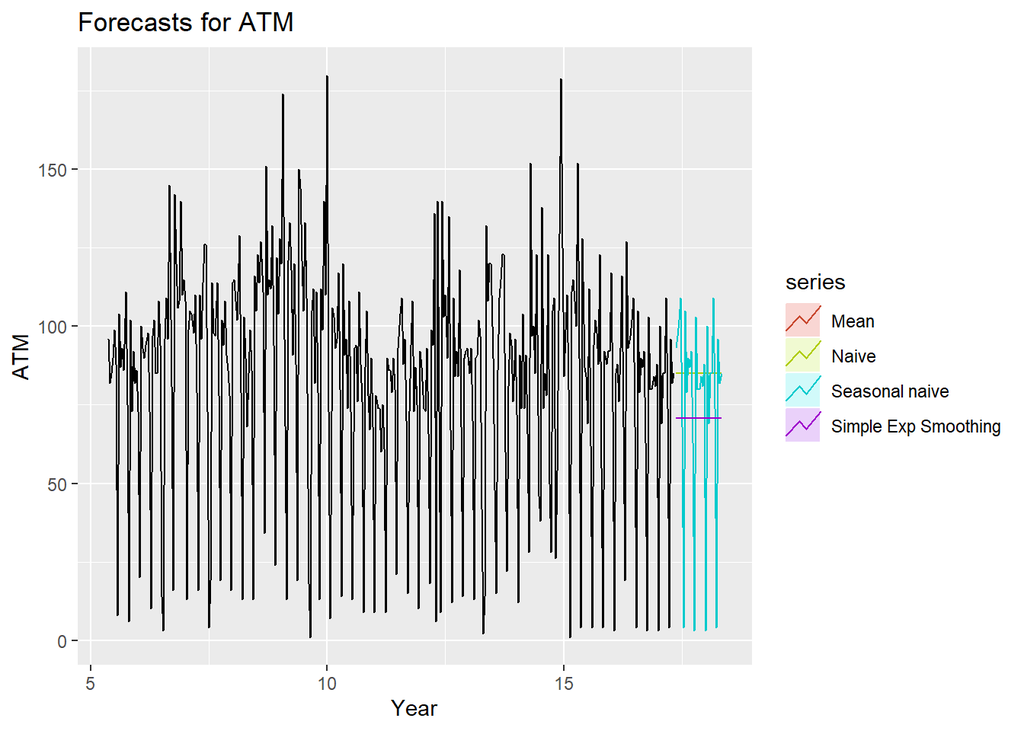

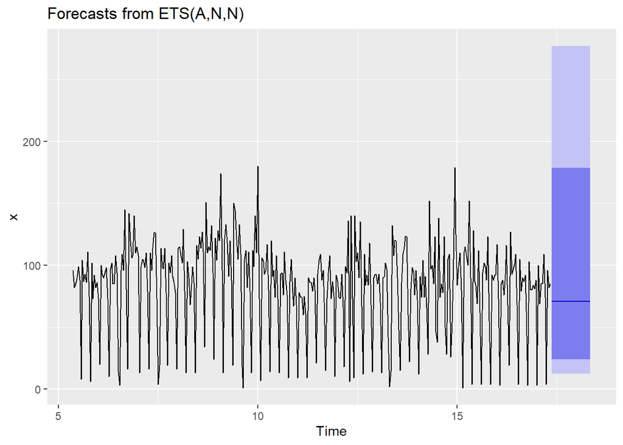

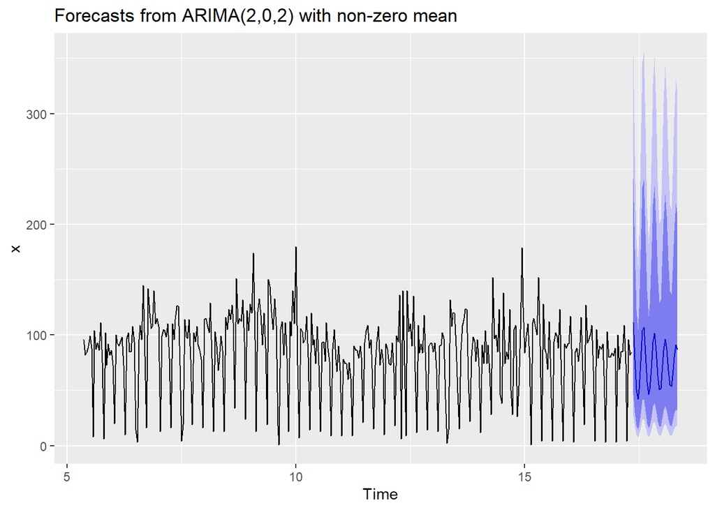

```r
modfunc(atm1,30)
```

### Train and Forecast

The forecast statistics for ATM1 shows that when comparing MSE of MEAN, NAIVE, SNAIVE and SES, the MEAN MSE is the lowest so would be the preferred model. The comparison of ETS and ARIMA, the low AIC/BIC values in ARIMA points to ARIMA as the best model. When looking at all of the training and test sets modeling stats MEAN and ARIMA appear to be the better models again.

```r
traintst(atm1,30)
```

```
## [1] "MEAN MSE:" "1381.94"
## [1] "NAIVE MSE:" "2656.79"
## [1] "SNAIVE MSE:" "3003.88"
## [1] "Simple Exp Smooth MSE:" "1385.95"
## [1] "ETS MSE:" "1389.07"
## [1] "ARIMA MSE:" "NaN"
## [1] "ETS AIC/BIC:"     "3216.369127172"   "3226.86064024099"
## [1] "ARIMA AIC/BIC:"   "854.743106907494" "882.385947014993"
## [[1]]
## [1] "Model1 MEAN:"
##
## [[2]]
##                     ME     RMSE      MAE       MPE      MAPE      MASE
## Training set 13.032020 39.18271 32.77504 -107.8262 149.13228 0.8055867
## Test set      6.136782 33.49093 26.26782  -27.8088  57.06424 0.6456438
##                    ACF1 Theil's U
## Training set  0.1088963        NA
## Test set     -0.1053549 0.4757379
##
## [[3]]
## [1] "Model2 NAIVE:"
##
## [[4]]
##                       ME     RMSE      MAE        MPE     MAPE     MASE
## Training set   0.1075697 49.36743 36.41833  -93.31956 127.6151 0.895136
## Test set     -44.4666667 55.32871 47.40000 -117.14408 119.1406 1.165058
##                    ACF1 Theil's U
## Training set -0.3484689        NA
## Test set     -0.1053549 0.6078271
##
## [[5]]
## [1] "Model3 SNAIVE:"
##
## [[6]]
##                      ME     RMSE      MAE        MPE      MAPE     MASE
## Training set  0.2342342 55.08258 40.68468 -157.15195 195.88306 1.000000
## Test set     -3.0333333 56.58180 42.56667  -54.64075  92.39117 1.046258
##                   ACF1 Theil's U
## Training set 0.1214694        NA
## Test set     0.2434163 0.7836573
```

[output cut: 18 more lines]

```
## Test set     -5.5146698 33.38254 25.53653  -48.37826  65.07291 0.6276694
##                     ACF1 Theil's U
## Training set  0.07640587        NA
## Test set     -0.10535488 0.4189047
##
## [[11]]
## [1] "Model6 ARIMA:"
##
## [[12]]
##                    ME     RMSE      MAE       MPE      MAPE      MASE
## Training set 9.162002 36.98278 30.06557 -71.14247 106.90900 0.7389898
## Test set     2.106441 35.69992 27.87114 -10.89320  39.29833 0.6850523
##                     ACF1 Theil's U
## Training set -0.05172762        NA
## Test set     -0.03130401 0.6224601
```

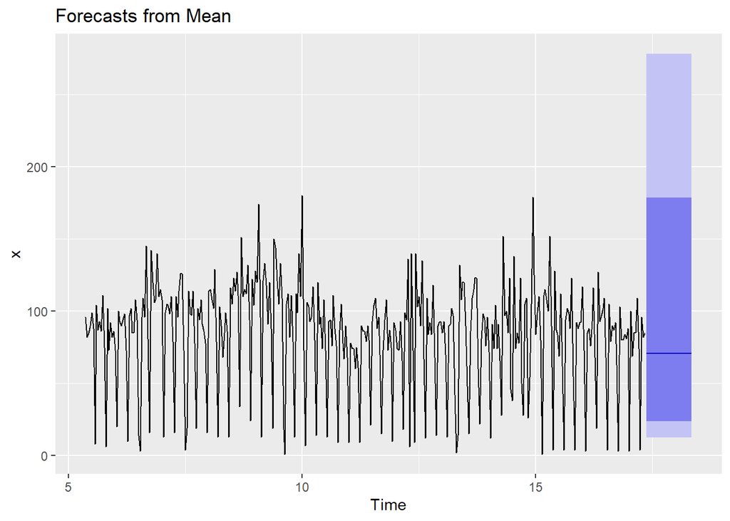

```r
train<- subset(atm1, end = nrow(atm1)*.7)

autoplot(forecast(m1,h=30))
```

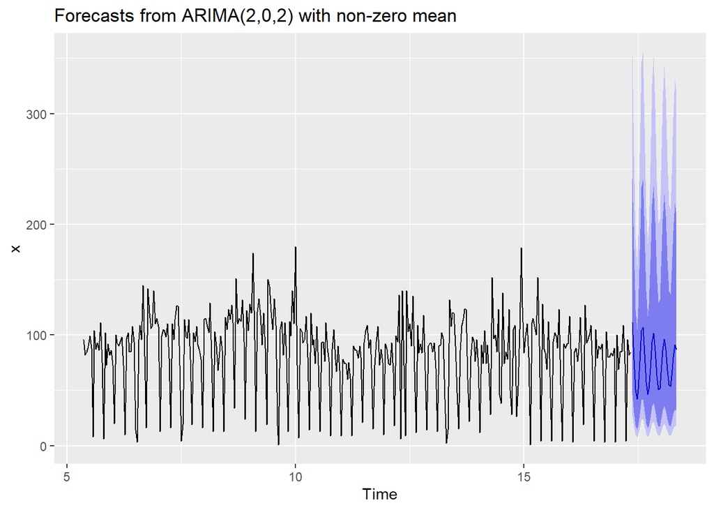

```r
autoplot(forecast(m6,h=30))
```

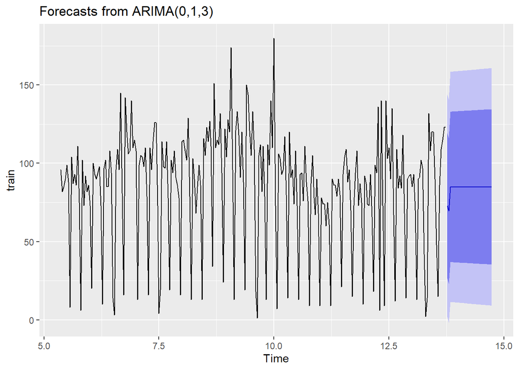

```r
autoplot(forecast(Arima(train, order= c(0,1,3)),h=30))
```

## Model Selection ATM1

Adding the differecing found in the KPSS function lowers the RMSE value. The final will use ARIMA with a level of differencing.

```r
print("MEAN MODEL")
```

```
## [1] "MEAN MODEL"
```

```r
accuracy(m1)
```

```
##                    ME     RMSE      MAE       MPE     MAPE     MASE      ACF1
## Training set 13.36035 38.91027 32.52735 -132.8602 174.8254 0.788513 0.0722071
```

```r
print("ARIMA MODEL")
```

```
## [1] "ARIMA MODEL"
```

```r
accuracy(m6)
```

```
##                  ME     RMSE      MAE       MPE     MAPE      MASE       ACF1
## Training set 9.7317 37.08896 30.54627 -94.54198 132.0839 0.7404883 0.05356851
```

```r
print("ARIMA MODEL with Differencing")
```

```
## [1] "ARIMA MODEL with Differencing"
```

```r
accuracy(Arima(train, order= c(0,1,3)))
```

```
##                      ME     RMSE      MAE      MPE     MAPE     MASE       ACF1
## Training set 0.04525908 35.93272 27.34182 -136.169 159.7153 0.672042 0.02222186
```

```r
m7<-Arima(train, order= c(0,1,3),lambda =l)

write.csv(forecast(m7, h=30),"atm1.csv")
```

## Diagnostics ATM2

### Check Data

In the check data portion for ATM2, we can see the basic autoplot for the original data shows some seasonality with a slight downtrend. The regression plot shows a residuals are farily symetrical. The ACF plot has a decreasing range while PAcf has several logs out out of the critical range. The series plot is an up and down trend for several months. The second checkresddual plot includes a Box Cox transformation based on box.cox.lambda function. The residual seems to stabalize a bit. The seasonal additive plot confirms the seasonality of the data with a downword trend and what appears to be a stationary remainder plot. The KPSS unit test shows that the original data is significant with 1 difference added.

```r
checkdata(atm2)
```

```
## [1] "Plot Data, Check Residuals , ACF ,PCF, seasonal and series Plots"
```

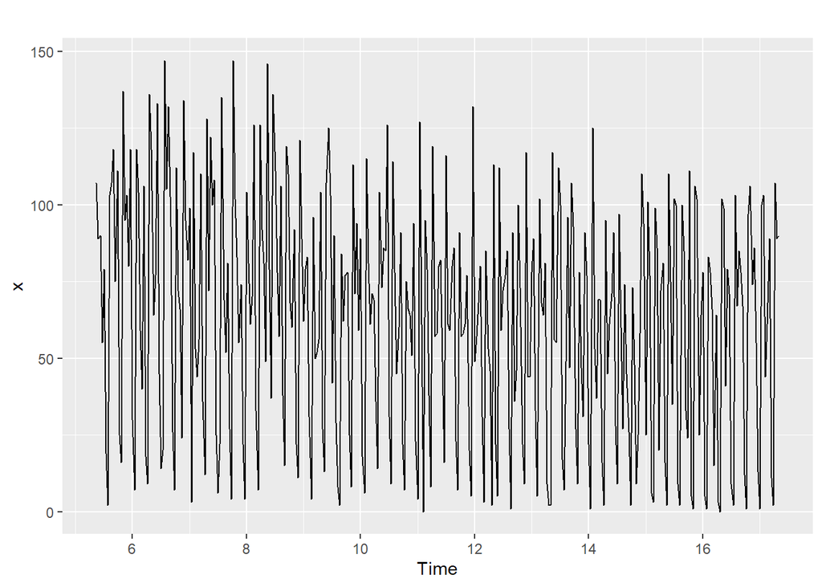

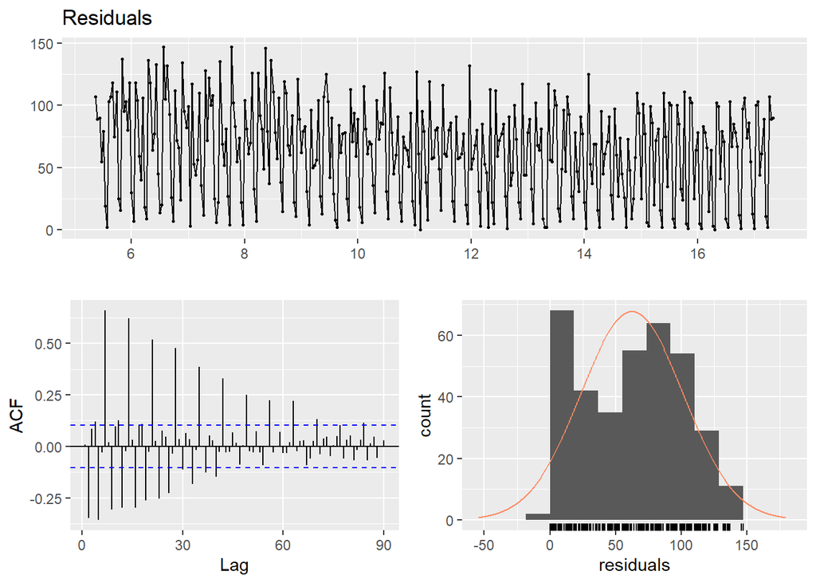

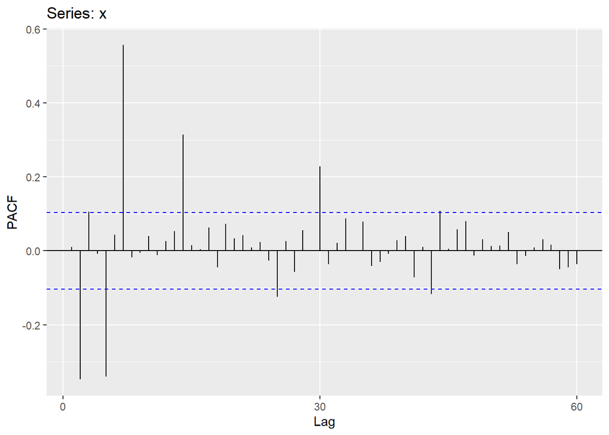

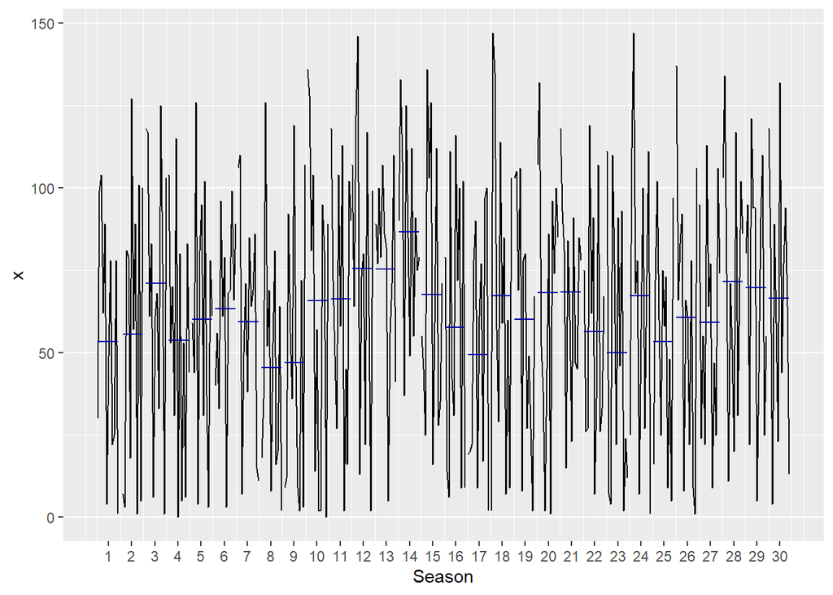

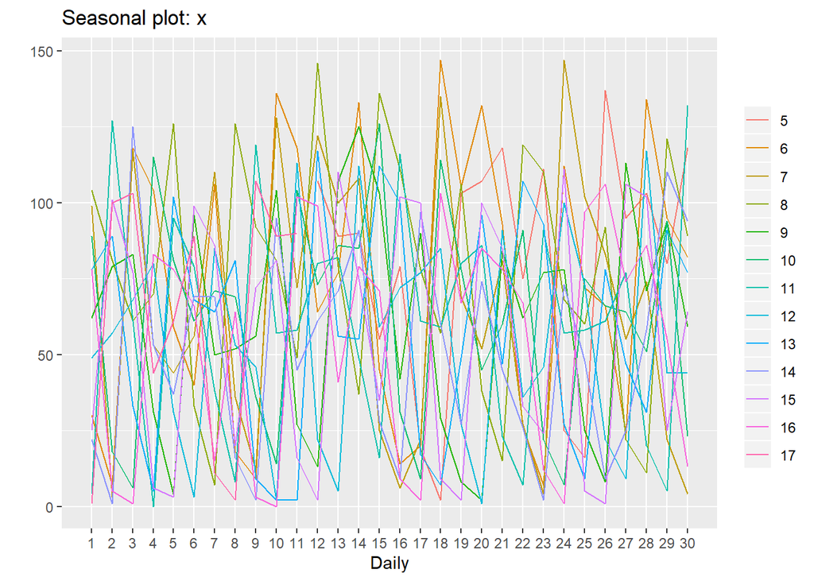

```
## [1] "Box Cox plots with Lambda"
```

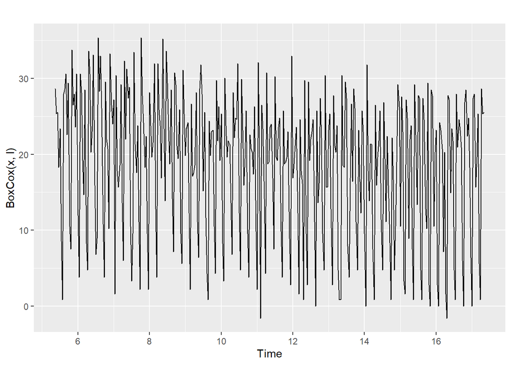

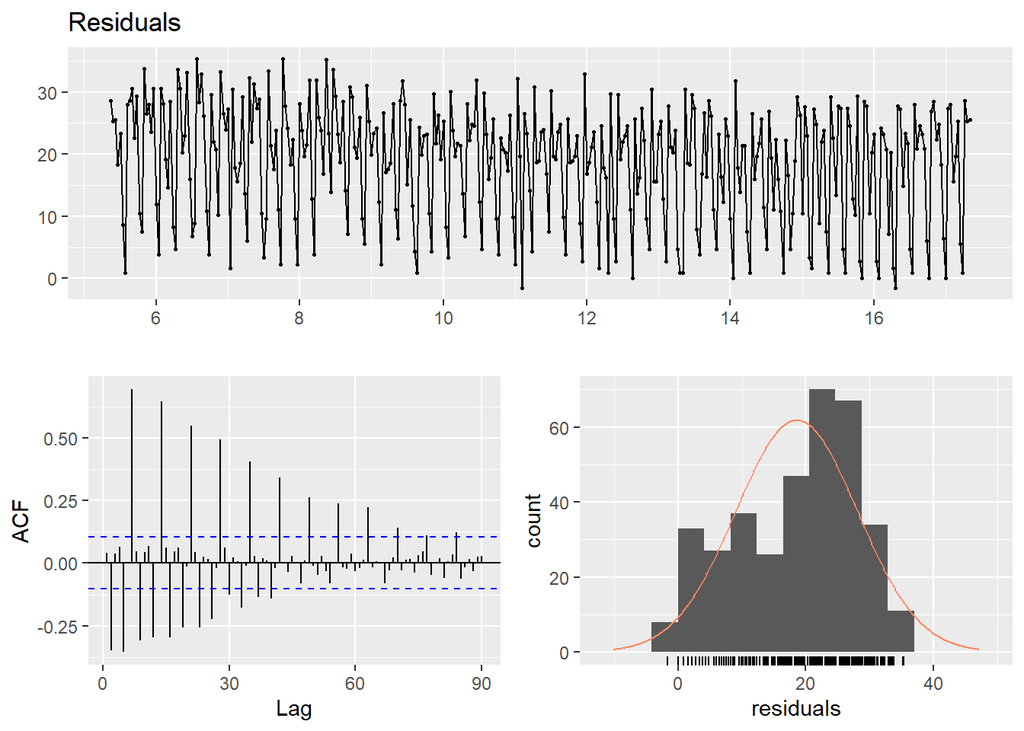

```
## NULL
## [1] "Plot data and seasonality Trends"
```

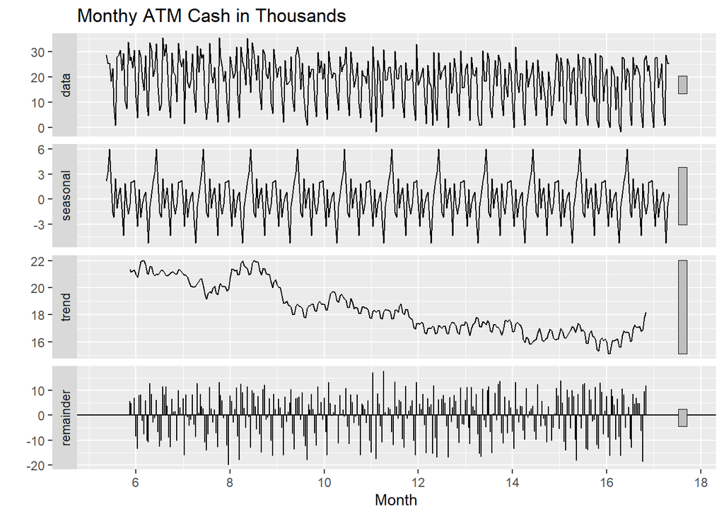

```
## [1] "Check if data or diff data is stationary"
##
## #######################
## # KPSS Unit Root Test #
## #######################
##
## Test is of type: mu with 5 lags.
##
## Value of test-statistic is: 2.0498
##
## Critical value for a significance level of:
##                 10pct  5pct 2.5pct  1pct
## critical values 0.347 0.463  0.574 0.739
##
##
## #######################
## # KPSS Unit Root Test #
## #######################
##
## Test is of type: mu with 5 lags.
##
## Value of test-statistic is: 0.0148
##
## Critical value for a significance level of:
##                 10pct  5pct 2.5pct  1pct
## critical values 0.347 0.463  0.574 0.739
##
##
##  KPSS Test for Trend Stationarity
##
## data:  atm1
## KPSS Trend = 0.12892, Truncation lag parameter = 5, p-value = 0.08163
```

### Model Data

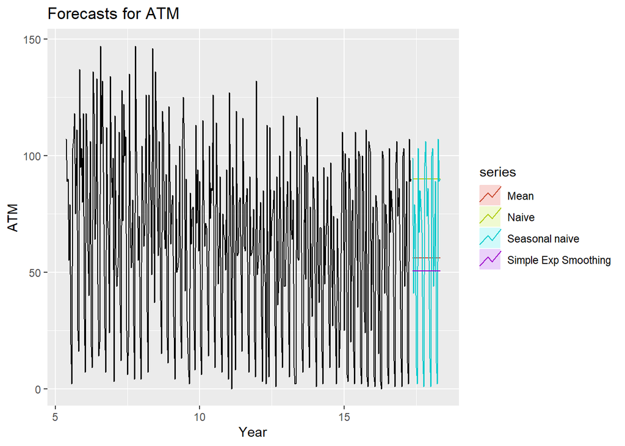

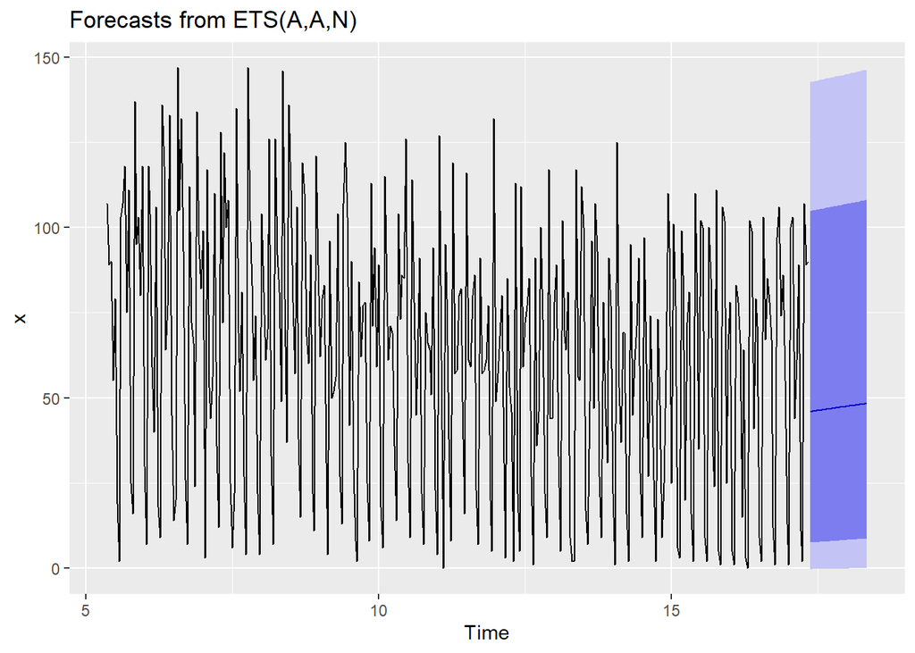

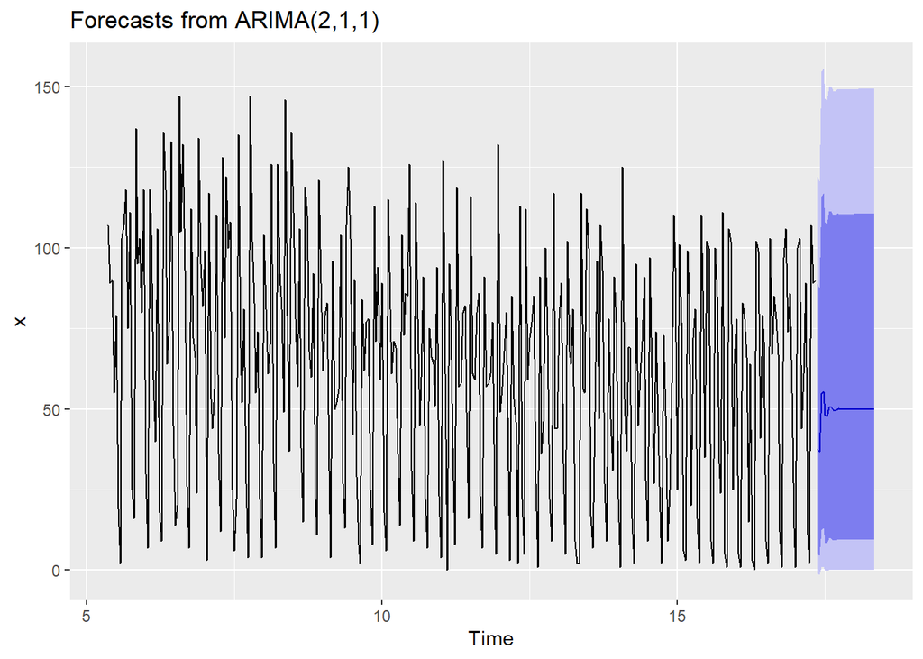

```r
modfunc(atm2,30)
```

### Train and Forecast

The forecast statistics for ATM2 shows that when comparing MSE of MEAN, NAIVE, SNAIVE and SES, the SES MSE is the lowest so would be the preferred model. When comparing the ETS and ARIMA models, the low AIC/BIC values in ARIMA points to ARIMA as the best model. When looking at all of the training and test sets modeling stats SES and ARIMA appear to be the better models again.

```r
traintst(atm2,30)
```

```
## [1] "MEAN MSE:" "1535.59"
## [1] "NAIVE MSE:" "2964.8"
## [1] "SNAIVE MSE:" "3385.64"
## [1] "Simple Exp Smooth MSE:" "1527.56"
## [1] "ETS MSE:" "1984.19"
## [1] "ARIMA MSE:" "NaN"
## [1] "ETS AIC/BIC:"     "3245.90486218249" "3263.30810518102"
## [1] "ARIMA AIC/BIC:"   "1817.30562870759" "1831.2448388381"
## [[1]]
## [1] "Model1 MEAN:"
##
## [[2]]
##                      ME     RMSE      MAE       MPE     MAPE      MASE
## Training set   5.794844 39.61949 33.65277      -Inf      Inf 0.6903452
## Test set     -10.328172 34.11433 29.01042 -456.1159 476.4671 0.5951131
##                      ACF1 Theil's U
## Training set -0.008771797        NA
## Test set     -0.128785848 0.5104452
##
## [[3]]
## [1] "Model2 NAIVE:"
##
## [[4]]
##                        ME     RMSE      MAE       MPE     MAPE      MASE
## Training set  -0.05577689 55.69324 43.69721      -Inf      Inf 0.8963945
## Test set     -43.50000000 54.30807 46.03333 -764.4553 766.5772 0.9443171
##                    ACF1 Theil's U
## Training set -0.3550064        NA
## Test set     -0.1287858 0.2515629
##
## [[5]]
## [1] "Model3 SNAIVE:"
##
## [[6]]
##                      ME     RMSE      MAE       MPE     MAPE     MASE
## Training set  -2.144144 57.67539 48.74775      -Inf      Inf 1.000000
## Test set     -10.433333 60.65943 53.10000 -559.3507 615.6813 1.089281
##                     ACF1 Theil's U
## Training set -0.06686785        NA
## Test set      0.01174909 0.7811541
```

[output cut: 18 more lines]

```
## Test set     -1.02577220 32.50325 27.93505 -369.5655 400.5625 0.5730532
##                     ACF1 Theil's U
## Training set -0.03610574        NA
## Test set     -0.12949476 0.5834659
##
## [[11]]
## [1] "Model6 ARIMA:"
##
## [[12]]
##                     ME     RMSE      MAE       MPE     MAPE      MASE
## Training set  1.226158 36.98974 31.70017      -Inf      Inf 0.6502900
## Test set     -3.006173 31.92579 27.21974 -387.7669 415.1714 0.5583794
##                    ACF1 Theil's U
## Training set -0.0756955        NA
## Test set     -0.1411202 0.5663431
```

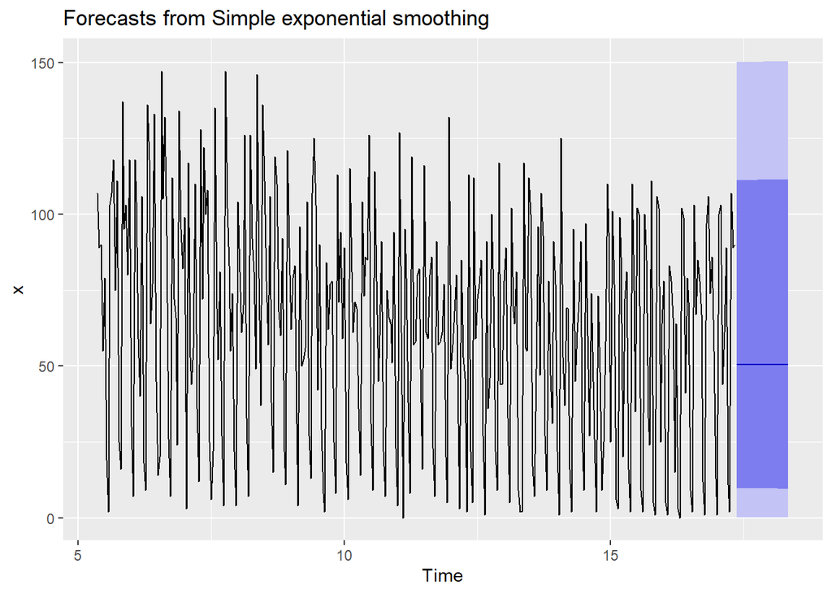

```r
autoplot(forecast(m4, h=30))
```

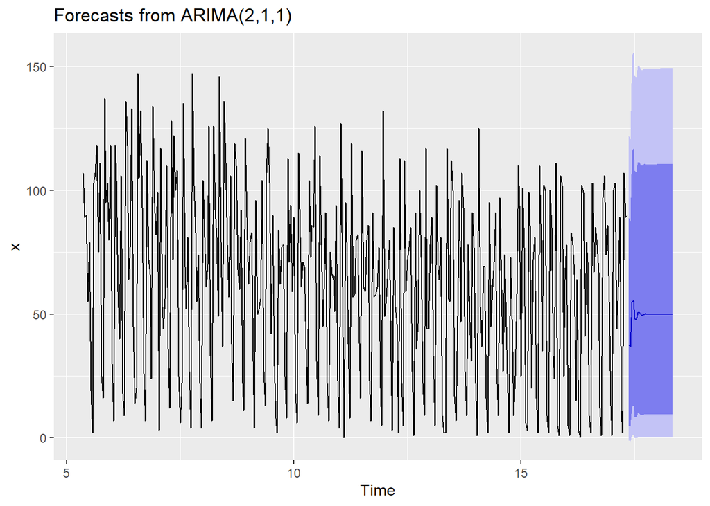

```r
autoplot(forecast(m6, h=30))
```

## Model Selection ATM2

Unlike ATM1 there is no need to add the differecing found in the KPSS function since the existing ARIMA Model alerady has it added. The final will use ARIMA model from m6.

```r
print("SES MODEL")
```

```
## [1] "SES MODEL"
```

```r
accuracy(m4)
```

```
##                    ME     RMSE      MAE  MPE MAPE      MASE        ACF1
## Training set 3.203627 38.82932 33.61801 -Inf  Inf 0.6843044 -0.01910277
```

```r
print("ARIMA MODEL")
```

```
## [1] "ARIMA MODEL"
```

```r
accuracy(m6)
```

```
##                    ME     RMSE      MAE  MPE MAPE      MASE        ACF1
## Training set 1.814027 35.84532 31.00939 -Inf  Inf 0.6312052 -0.07107226
```

```r
write.csv(forecast(m6, h=30),"atm2.csv")
```